# Integrating Python and Machine Learning — Building a Pitching Change Model for Baseball Games

113048230 Jacky Hung & 113193510 Max Lin

2025-06-02

## Abstract

This study explains the construction and implementation of a predictive model for the timing of starting pitcher substitutions under Major League Baseball’s pitch clock policy. The data were obtained from Baseball Savant (2011–2024, 40 pitchers, totaling 686,149 pitches). After Python-based feature engineering, customized variables were extracted, including cumulative pitch count (pitch_count), differences in velocity and spin rate (release_speed_diff, release_spin_rate_diff), cumulative base runners (reach_base), and recent five plate appearances (last_5). Substitution cases (change=1) were treated as positive examples, and only a One-Class SVM model was trained to detect abnormal patterns. The model normalized decision_scores, applied 0.9 as the alert threshold, and automatically flagged “warning!!!” and “change!!!” based on multi-step continuous alert rules. The simulated game results showed that the probability of substitution clearly increased with pitch count, and the timing of alerts matched coaches’ intuition, demonstrating the effectiveness of the selected features and parameter settings. This study also emphasizes reproducibility through code version control and environment configuration, and recommends incorporating more game-related, physiological, and tactical variables in future applications to further improve predictive accuracy.

## Introduction

In baseball, regardless of the league, determining the correct timing for a pitching change has always been a goal that every coach relentlessly pursues. To predict whether a starting pitcher can still maintain stable performance at a given moment, it is necessary not only to assess his current condition but also to comprehensively consider multiple factors such as the game situation, as well as the pitcher’s physical and psychological state. Even a slight error in judgment may cause the team to lose a critical situation and even change the course of the entire game. For example, when a pitcher reaches the stage of fatigue, the risk of being strategically targeted by batters increases significantly; accordingly, coaches also take such practical judgments into account when deciding on substitutions. Therefore, in designing our model, we incorporate these practical conditions so that the analytical results align more closely with the actual decision-making needs of coaches.  
In the subsequent chapters, we will introduce how version control can be used to manage the code and how data processing and model implementation are divided into clear modules to facilitate team collaboration and maintenance. In addition, to ensure the reproducibility of all written content, we will also describe the environment configuration used during programming, including the package versions and required hardware specifications, so that others can quickly set up the same analytical environment. Finally, we will provide sufficient code comments and documentation to help readers easily understand the function and purpose of each piece of code, thereby further enhancing the readability and shareability of the research outcomes.

## Research Question

This study will focus on  
1. How can existing data and models be used to accurately predict a starting pitcher’s pitch count and substitution timing within a single game?

We want to know whether, by organizing pitchers’ basic information and pitch-by-pitch timing data, it is possible to build a tool that allows coaches to make real-time judgments during a game about whether a starting pitcher can continue performing effectively, and approximately when he is likely to be substituted. Such predictions can support in-game decision-making and reduce risks caused by delayed or insufficient observations.

## Research Tool

This study uses Jupyter Notebook as the primary environment for analysis and development. Jupyter Notebook is a web-based interactive computing platform that integrates code, explanatory text, and visualizations within a single document, making it convenient to dynamically present analytical results.  
Through its seamless integration with commonly used packages such as pandas and matplotlib, we are able to perform data preprocessing, feature engineering, and model validation in real time, while easily embedding code and visualizations into the report. This enhances both the efficiency and the reproducibility of the research process.  
All programs were written in Python. From data loading, cleaning, and feature engineering to model training and evaluation, the process relied on the rich ecosystem of Python libraries (such as scikit-learn, numpy, and pandas). In the study, Python scripts were invoked directly through Jupyter code cells, with modular functions written to address the computational needs of different stages. This design not only improves the maintainability of the overall workflow but also enables rapid testing of various algorithms and parameter combinations.  
In addition, the presentation of this report was written in R Markdown to document the analytical process. The .rmd file was first compiled into HTML to ensure readability with proper formatting of text, figures, and code highlighting. The generated HTML file was then pushed to GitHub Pages or directly published in the form of a repository, allowing an online URL to be obtained. This approach enhances the portability and shareability of the report.

## Research Method

This study initially employed XGBoost (Extreme Gradient Boosting) and Logistic Regression classifiers. However, the former is essentially an extension of decision trees, while the latter assumes a linear relationship between the independent variables and the target—an assumption we could not verify. Furthermore, the dataset used for training was highly imbalanced, with far fewer samples labeled as 1 (substitution) compared to 0 (no substitution). As a result, the trained models often became overly conservative or overly optimistic, leading to substitution timings that contradicted practical intuition. Therefore, we adopted the One-Class SVM (Support Vector Machine) approach for training and modeling.  
Unlike traditional SVM, the One-Class SVM belongs to unsupervised learning. In model training, it only requires one type of data (usually positive observations), with the goal of constructing a boundary for “normal” data in order to detect anomalous samples. In our training data, rows representing substitution cases are treated as normal, while non-substitution cases are considered abnormal. Our aim is that when the model evaluates the pitch records of a starting pitcher in a given game, it can determine whether the pitching information at that moment corresponds to a normal substitution scenario (output value = 1), thereby enabling substitution prediction.

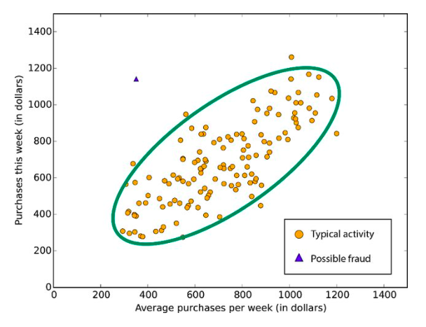

Figure1. One-Class SVM

## Research Data

The characteristics of the training data used in this study are as follows:  
1. From Baseball Savant.  
2. Pitching data from a total of 40 pitchers.  
3. The time span is from 2011 to 2024.  
4. A total of 686,149 pitches and 175,910 plate appearances.  
5. The data are presented in CSV format.

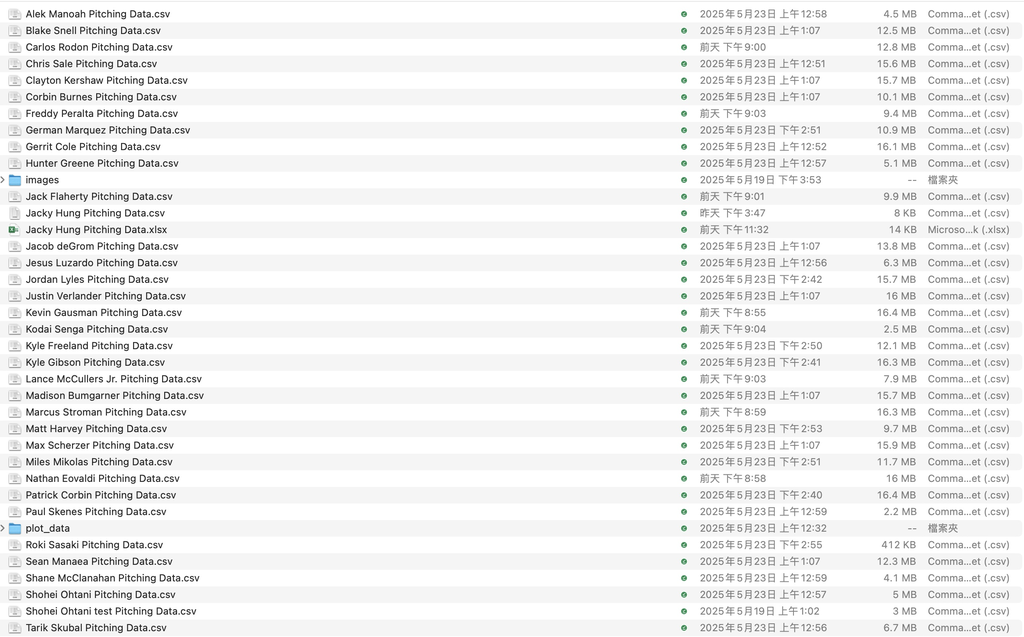

Figure2. Training data files

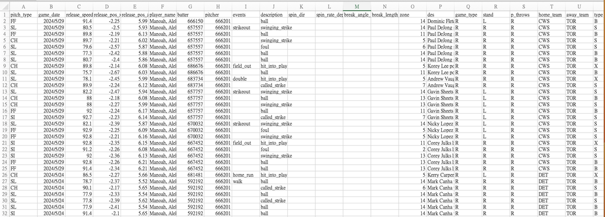

Figure3. Inside the raw training data